# Presentation Linear Regression

Guan Tsern Kuo

West Chester University

# 1 Introduction

Linear regression is one of the simplest predictive modeling algorithms that can predict the value of the dependent variable by considering only one independent variable. The variable to be predicted is called the dependent variable. The variable used to predict the value of another variable is called the independent variable.

# 2 Defination

Linear regression is an algorithm that shows a linear relationship between an independent variable and a dependent variable.

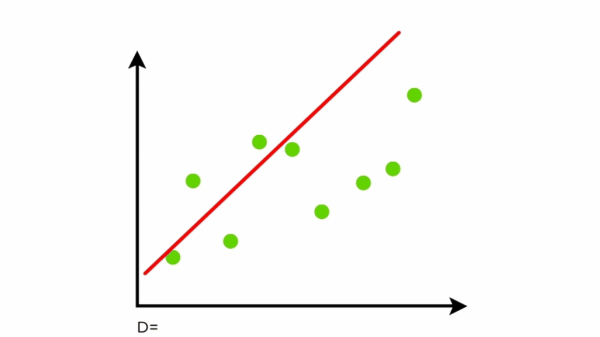

# 3 Mathematical Formulas

Y is dependent variable β0 is bias term β1,β2,…βn are coefficient x1,x2,…xn are independent variable ε is random error

An example of inline equation $y=\beta_0+\beta_1x_1+\cdots+\beta_kx_k+\epsilon$, where $\epsilon \sim N(0, \sigma^2)$.

# 4 Assumptions associated with a linear regression model

- Linearity: The relationship between X and the mean of Y is linear.
- Homoscedasticity: The variance of residual is the same for any value of X.
- Independence: Observations are independent of each other.
- Normality: For any fixed value of X, Y is normally distributed.

# 5 Case example 1 Raw Data Table

|  | Height | Weight |
| --- | --- | --- |
| 1 | 150 | 63 |
| 2 | 184 | 82 |
| 3 | 138 | 56 |
| 4 | 185 | 90 |
| 5 | 128 | 46 |
| 6 | 135 | 54 |
| 7 | 178 | 76 |
| 8 | 162 | 78 |
| 9 | 152 | 66 |
| 10 | 121 | 48 |

## 5.1 Case example 1 in predicting weight

Predicted weight for a person with a height of 160 cm in a linear regression model.

```r
# The predictor vector.
x <- c(150, 184, 138, 185, 128, 135, 178, 162, 152, 121)

# The resposne vector.
y <- c(63, 82, 56, 90, 46, 54, 76, 78, 66, 48)

# Apply the lm() function.
linreg <- lm(y~x)
# Find weight of a person with height 160.
a <- data.frame(x = 160)
result <-  predict(linreg,a)
print(result)
```

```
      1
70.1039
```

Predicted weight is equal to 70.1039 kg.

## 5.2 PLOT

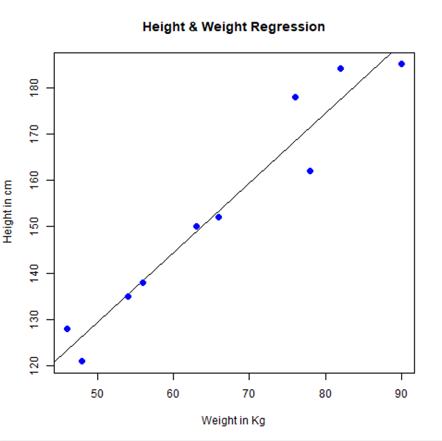

$y=-30.28768+0.62745*X$

# 6 Case example 2 Raw Data Table

```r
penguins = read.csv("https://raw.githubusercontent.com/GUANTSERN-KUO/webcv/main/w03/w03-penguins.csv")

penguins.new <- na.omit(penguins)

penguins.new =
  filter(penguins.new, (species == "Adelie" | species == "Gentoo")
            & (island == "Biscoe" | island == "Torgersen" )
            & (5000 > body_mass_g & body_mass_g > 3500) )

penguins.new$BMI <- penguins.new$body_mass_g/(4000)

penguins.new <- subset(penguins.new, select = -c(X,body_mass_g,sex,year ))
```

|  | species | island | bill_length_mm | bill_depth_mm | flipper_length_mm | BMI |
| --- | --- | --- | --- | --- | --- | --- |
| 1 | Adelie | Torgersen | 39.1 | 18.7 | 181 | 0.9375 |
| 2 | Adelie | Torgersen | 39.5 | 17.4 | 186 | 0.95 |
| 3 | Adelie | Torgersen | 39.3 | 20.6 | 190 | 0.9125 |
| 4 | Adelie | Torgersen | 38.9 | 17.8 | 181 | 0.90625 |
| 5 | Adelie | Torgersen | 39.2 | 19.6 | 195 | 1.16875 |
| 6 | Adelie | Torgersen | 38.6 | 21.2 | 191 | 0.95 |
| 7 | Adelie | Torgersen | 34.6 | 21.1 | 198 | 1.1 |
| 8 | Adelie | Torgersen | 36.6 | 17.8 | 185 | 0.925 |
| 9 | Adelie | Torgersen | 42.5 | 20.7 | 197 | 1.125 |
| 10 | Adelie | Torgersen | 46 | 21.5 | 194 | 1.05 |

[output cut: 101 more lines]

## 6.1 Descriptive Statistic & Variables Relationship

- flip : Penguins flipper length (mm)
- bill : Penguins bill length (mm)
- BMI: Penguins body mass / 4000 (grams)

```r
flip = summary(penguins.new$flipper_length_mm )

bill = summary(penguins.new$bill_length_mm )
BMI = summary(penguins.new$BMI )


list(flip = flip, bill = bill, BMI=BMI)
```

```
$flip
   Min. 1st Qu.  Median    Mean 3rd Qu.    Max.
  180.0   191.0   200.0   201.5   212.0   222.0

$bill
   Min. 1st Qu.  Median    Mean 3rd Qu.    Max.
  33.50   39.55   42.70   42.46   45.75   49.60

$BMI
   Min. 1st Qu.  Median    Mean 3rd Qu.    Max.
 0.8875  0.9719  1.0750  1.0697  1.1750  1.2437
```

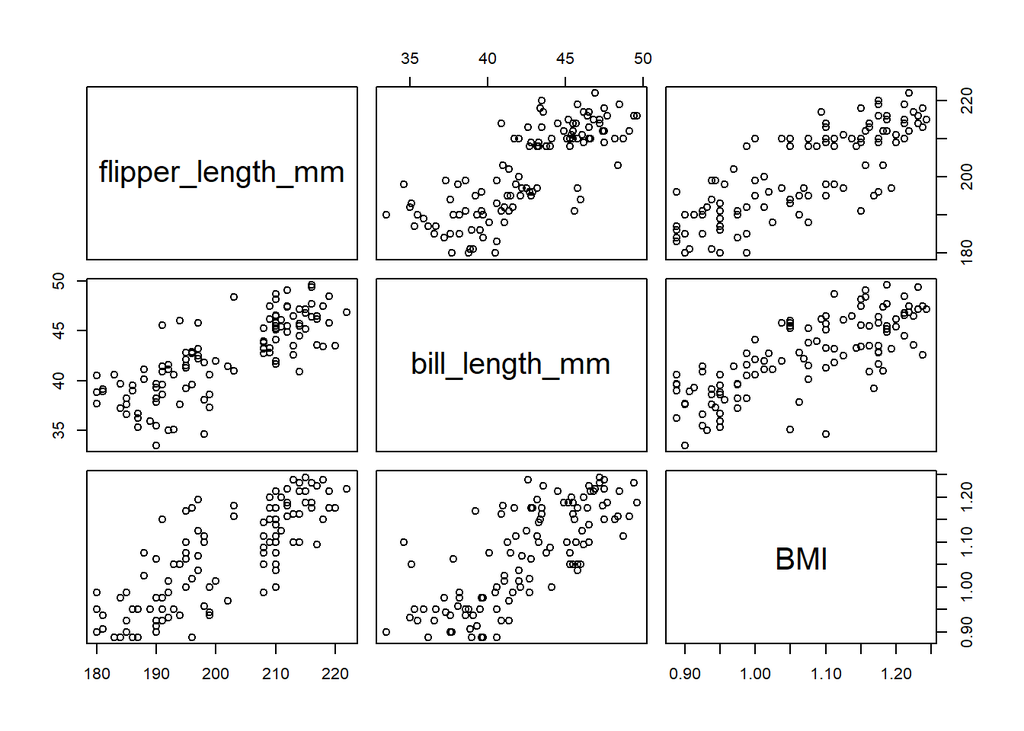

```r
pen <- c("flipper_length_mm", "bill_length_mm", "BMI")
DB <- penguins.new[pen]
pairs(DB)
```

- flipper_length_mm : Penguins flipper length (mm)
- bill_length_mm : Penguins bill length (mm)
- BMI: Penguins body mass / 4000 (grams)

From the above figure, it is positive linear relationship between flipper_length_mm and BMI. Moreover, it is positive linear relationship between bill_length_mm and BMI.

## 6.2 The relationship between Bill legnth and Flipper length across 2 species

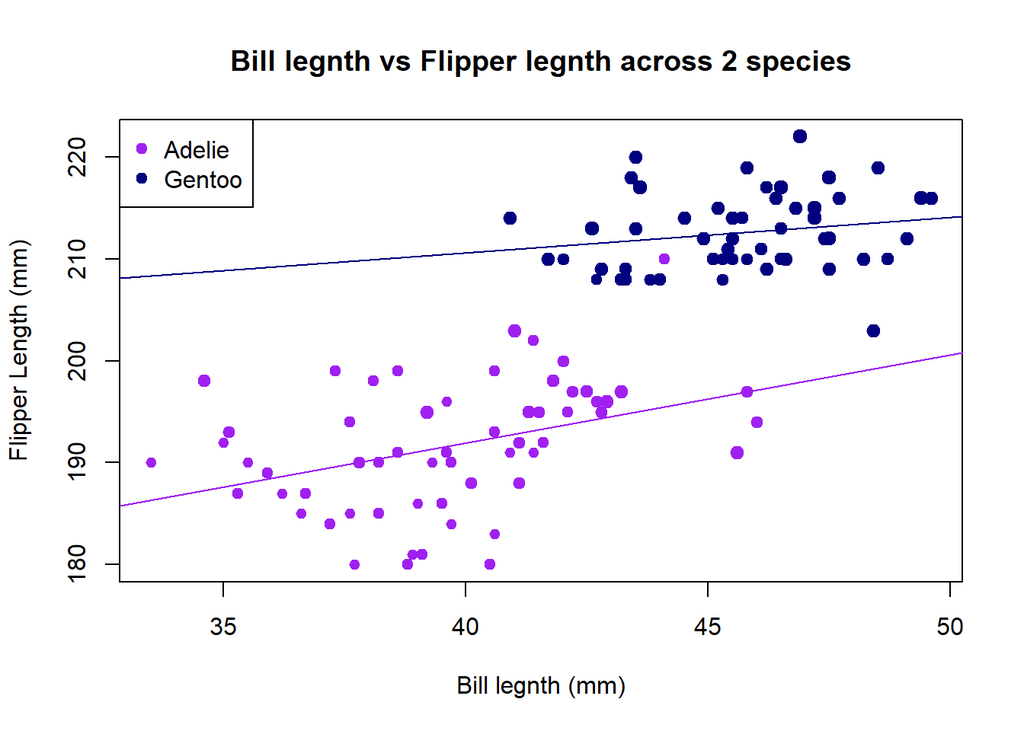

```r
pg.img <- "https://raw.githubusercontent.com/GUANTSERN-KUO/webcv/main/w03/img2/penguin.jpeg"
my.pg <- readJPEG(getURLContent(pg.img))
raster.pg <- as.raster(my.pg)

# Use the code in the precious section
Bill.length = penguins.new$bill_length_mm
Flipper.length = as.numeric(penguins.new$flipper_length_mm)
size.body = as.numeric(penguins.new$BMI)

species = penguins.new$species

## identifying the ID
Adelie.id = which(species=="Adelie")  # value are case sensitive!
Gentoo.id = which(species=="Gentoo")


## making an empty plot: type = "n" ==> no point
plot(Bill.length, Flipper.length, main = "Bill legnth vs Flipper legnth across 2 species", type = "n" ,  xlab = "Bill legnth (mm)", ylab = "Flipper Length (mm)")

points(Bill.length[Adelie.id], Flipper.length[Adelie.id],
       pch = 19, col = "purple", cex = size.body[Adelie.id])

points(Bill.length[Gentoo.id], Flipper.length[Gentoo.id],
       pch = 19, col = "navy", cex = size.body[Gentoo.id])


legend("topleft", c("Adelie", "Gentoo"),
                  col=c("purple", "navy"),
                  pch=c(19, 19))

#rasterImage(raster.pg,57,190,60,220)

# plot a regression line
abline(lm(Flipper.length[Adelie.id]~Bill.length[Adelie.id]),col='purple')

abline(lm(Flipper.length[Gentoo.id]~Bill.length[Gentoo.id]),col='navy')
```

From above the figure, most Gentoo penguins have longer flipper and longer bill than Adelie penguins. In addition, there is a positive linear relationship between flipper length and bill length in both the Gentoo and Adelie penguin studies.

# 7 Case example 3 Raw Data Table

```r
#read data files from GitHub
I.P.P = read.csv("https://raw.githubusercontent.com/GUANTSERN-KUO/webcv/main/w05/income_per_person.csv")

L.E.Y = read.csv("https://raw.githubusercontent.com/GUANTSERN-KUO/webcv/main/w05/life_expectancy_years.csv")


countrytot = read.csv("https://raw.githubusercontent.com/GUANTSERN-KUO/webcv/main/w05/countries_total.csv")


poptot = read.csv("https://raw.githubusercontent.com/GUANTSERN-KUO/webcv/main/w05/population_total.csv")


#transpose data from wide to long

IPPlong <- melt(setDT(I.P.P),value.name = "income", id.vars = c("geo"), variable.name = "year")

LEYlong <- melt(setDT(L.E.Y),value.name = "life_expectancy", id.vars = c("geo"), variable.name = "year")

poptotlong <- melt(setDT(poptot),value.name = "pop_size", id.vars = c("geo"), variable.name = "year")


## remove string X
IPPlong$year<-gsub("X","",as.character(IPPlong$year))
LEYlong$year<-gsub("X","",as.character(LEYlong$year))
poptotlong$year<-gsub("X","",as.character(poptotlong$year))


#merge Income Per Person and Life Expectancy in Years
LifeExpIncom <- merge(LEYlong, IPPlong, by = c("geo", "year"),
                      all = TRUE)

#Create database
con <- dbConnect(drv = SQLite(),
                 dbname = ":memory:")

#store sample data in database
dbWriteTable(conn = con,
             name = "LEYlong",
             value = LEYlong)

dbWriteTable(conn = con,
             name = "IPPlong",
             value = IPPlong)

dbWriteTable(conn = con,
             name = "LifeExpIncom",
             value = LifeExpIncom)

dbWriteTable(conn = con,
             name = "countrytot",
             value = countrytot)

dbWriteTable(conn = con,
             name = "poptotlong",
             value = poptotlong)
```

```sql
SELECT a.*, b.region
FROM LifeExpIncom AS A
LEFT JOIN countrytot AS B
ON A.geo = B.name;
```

```r
#store sample data in database
dbWriteTable(conn = con,
             name = "life2",
             value = life2)
```

```sql
SELECT a.*, b.pop_size
FROM life2 AS A
LEFT JOIN poptotlong AS B
ON A.geo = B.geo AND A.year = B.year ;
```

```r
# write final data to csv file
write.csv(x = final, file = "final.csv", row.names = FALSE)
```

```r
# read final file
final = read.csv("https://raw.githubusercontent.com/GUANTSERN-KUO/webcv/main/w05/final.csv")



data2000 <- filter(final,year==2000)  # create 2000data
```

|  | geo | year | life_expectancy | income | region | pop_size |
| --- | --- | --- | --- | --- | --- | --- |
| 1 | Afghanistan | 2000 | 51.6 | 972 | Asia | 20100000 |
| 2 | Albania | 2000 | 74.4 | 5470 | Europe | 3120000 |
| 3 | Algeria | 2000 | 73.9 | 10200 | Africa | 31200000 |
| 4 | Andorra | 2000 | 81.8 | 31700 | Europe | 65400 |
| 5 | Angola | 2000 | 53.4 | 3510 | Africa | 16400000 |
| 6 | Antigua and Barbuda | 2000 | 74.7 | 18800 | Americas | 83600 |
| 7 | Argentina | 2000 | 74.2 | 14900 | Americas | 37100000 |
| 8 | Armenia | 2000 | 71.8 | 2930 | Asia | 3070000 |
| 9 | Australia | 2000 | 79.7 | 35300 | Oceania | 19100000 |
| 10 | Austria | 2000 | 78.1 | 38800 | Europe | 8070000 |

[output cut: 183 more lines]

## 7.1 Descriptive Statistic & Variables Relationship

- geo : geography
- pop_size : population size

```r
summary(final)
```

```
     geo                 year      life_expectancy     income
 Length:42267       Min.   :1800   Min.   : 1.00   Min.   :   247
 Class :character   1st Qu.:1854   1st Qu.:31.20   1st Qu.:   877
 Mode  :character   Median :1909   Median :35.50   Median :  1450
                    Mean   :1909   Mean   :43.13   Mean   :  4691
                    3rd Qu.:1964   3rd Qu.:56.00   3rd Qu.:  3520
                    Max.   :2018   Max.   :84.20   Max.   :178000
                                   NA's   :1830
    region             pop_size
 Length:42267       Min.   :1.830e+03
 Class :character   1st Qu.:3.130e+05
 Mode  :character   Median :1.770e+06
                    Mean   :1.312e+07
                    3rd Qu.:6.045e+06
                    Max.   :1.420e+09
```

## 7.2 The relationship between Income and Life Expectancy across Region

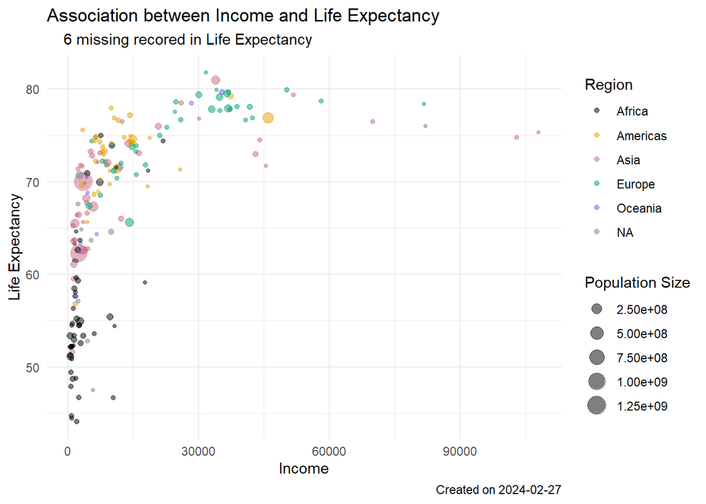

```r
cols1 = c("#000000","#E69F00","#CC6677","#009E73","#785EF0","#D55E00")
ggplot(data2000, aes(x = income, y = life_expectancy,
                              color = region,
                              size = pop_size)) +
             geom_point(alpha = 0.5) +
             scale_color_manual(values = cols1) +
             labs(
                 x = "Income",
                 y = "Life Expectancy",
                 # label for legends
                 size = "Population Size",
                 color = "Region",
                 title = "Association between Income and Life Expectancy",
                 subtitle = "    6 missing recored in Life Expectancy ",
                 caption = paste("Created on", Sys.Date())) +
             theme_minimal()   # minimal theme
```

Most people in the European region have higher incomes and higher levels of life expectancy. And most people in the African region have lower incomes and lower levels of life expectancy.